# lab_08_modeling1

Analysis of Environmental Data Lab 634

Emma Zimmerman Greenlee

2021-11-03

# Prelab

### Load the Data Files

```r
require(here)
dat_hab = read.csv(here("data", "hab.sub.csv"))
head(dat_hab)
```

```
##   basin sub sub.lat sub.long sub.elev road.den stream.den     ta p.mps p.tcai
## 1     D  AL 4923007 437086.9      635       19         29 292.17 17.19  25.59
## 2     D  BC 4920180 430610.5      533        1         28 247.91 22.54  16.01
## 3     D  CH 4929243 436373.8      396       11         32 291.08 10.04  11.41
## 4     D  DC 4932834 430564.8      342       18         32 286.92 17.93  18.66
## 5     D  HC 4931820 428852.7      369       30         30 271.44 11.80  20.05
## 6     D  LF 4930588 432246.9      327       34         38 250.09 11.91  18.54
##   p.sidi p.siei p.contag  p.ed p.cwed p.teci s.mps s.tcai s.sidi s.siei
## 1   0.70   0.80    62.97 68.33  16.97  21.83 58.43  62.37   0.12   0.16
## 2   0.63   0.85    47.32 61.59   7.15   9.23 61.98  59.21   0.34   0.50
## 3   0.80   0.87    69.69 72.86  24.67  28.17 22.39  28.33   0.78   0.88
## 4   0.72   0.83    69.42 60.06  20.81  28.89 35.87  33.51   0.57   0.76
## 5   0.84   0.93    70.15 65.46  25.06  30.81 16.97  21.77   0.84   0.94
## 6   0.80   0.87    69.74 76.93  22.67  26.09 25.01  25.51   0.73   0.84
##   s.contag  s.ed s.cwed s.teci    b   ccp ccs    cf   cls  cop  cos csh    g
```

[output cut: 20 more lines]

```r
dat_bird = read.csv(here("data", "bird.sub.csv"))
head(dat_bird)
```

```
##   basin sub tsta AMCR AMDI       AMGO      AMRO    BAEA       BASW       BCCH
## 1     D  AL   35    0    0 0.28571429 0.5428571 0.00000 0.00000000 0.00000000
## 2     D  BC   32    0    0 0.09375000 0.3125000 0.00000 0.00000000 0.00000000
## 3     D  CH   37    0    0 0.05405405 0.5945946 0.00000 0.05405405 0.05405405
## 4     D  DC   34    0    0 0.02941176 0.5588235 0.00000 0.00000000 0.00000000
## 5     D  HC   35    0    0 0.31428571 0.5142857 0.00000 0.00000000 0.08571429
## 6     D  LF   32    0    0 0.53125000 0.4687500 0.03125 0.00000000 0.15625000
##         BEKI       BEWR       BGWA       BHCO      BHGR       BRCR      BTPI
## 1 0.00000000 0.05714286 0.02857143 0.02857143 0.4285714 0.02857143 0.4857143
## 2 0.00000000 0.03125000 0.03125000 0.00000000 0.4062500 0.43750000 0.2500000
## 3 0.05405405 0.02702703 0.08108108 0.00000000 0.7567568 0.37837838 0.8378378
## 4 0.00000000 0.00000000 0.05882353 0.00000000 0.6176471 0.55882353 0.6470588
## 5 0.02857143 0.28571429 0.00000000 0.02857143 0.7142857 0.34285714 0.4000000
## 6 0.00000000 0.25000000 0.12500000 0.03125000 0.8437500 0.28125000 0.5937500
##   BUGR       BUSH       CAGO      CBCH      CEWA COHA      COME       CONI
```

[output cut: 83 more lines]

```r
veg = read.csv(here("data", "vegdata.csv"))
head(veg)
```

```
##   block plot date treatment birch pine fern
## 1     A   A3 1995   control     0    4  260
## 2     A   A7 1995   control     0    0  186
## 3     A   A4 1995   removed     8    8   46
## 4     A   A6 1995   removed     6   28    1
## 5     A   A5 1995     mixed     0    1  309
## 6     A   A8 1995     mixed     0    0  258
```

## Bootstrap: Continous Data

### Bootstrap: Exploring the Alternative Hypothesis

### Penguin Data

```r
require(palmerpenguins)
penguin_dat = droplevels(subset(penguins, species != "Gentoo"))
```

### Parametric Two-Sample Test

```r
t.test(flipper_length_mm ~ species, data = penguin_dat, alternative = "less")
```

```
##
##  Welch Two Sample t-test
##
## data:  flipper_length_mm by species
## t = -5.7804, df = 119.68, p-value = 3.025e-08
## alternative hypothesis: true difference in means between group Adelie and group Chinstrap is less than 0
## 95 percent confidence interval:
##       -Inf -4.186534
## sample estimates:
##    mean in group Adelie mean in group Chinstrap
##                189.9536                195.8235
```

### Bootstrap Two-Sample Test

```r
# install.packages("boot")
require(boot)
# install.packages("simpleboot")
require(simpleboot)
adelie = subset(penguin_dat, species == "Adelie")
chinstrap = subset(penguin_dat, species == "Chinstrap")

boot_mean = function(x, i)
{
  return(mean(x[i], na.rm = TRUE))
}

pen_boot =
  two.boot(
    adelie$flipper_length_mm,
    chinstrap$flipper_length_mm,
    boot_mean,
    10000)
head(pen_boot)
```

[output not shown]

[output cut: 10131 more lines]

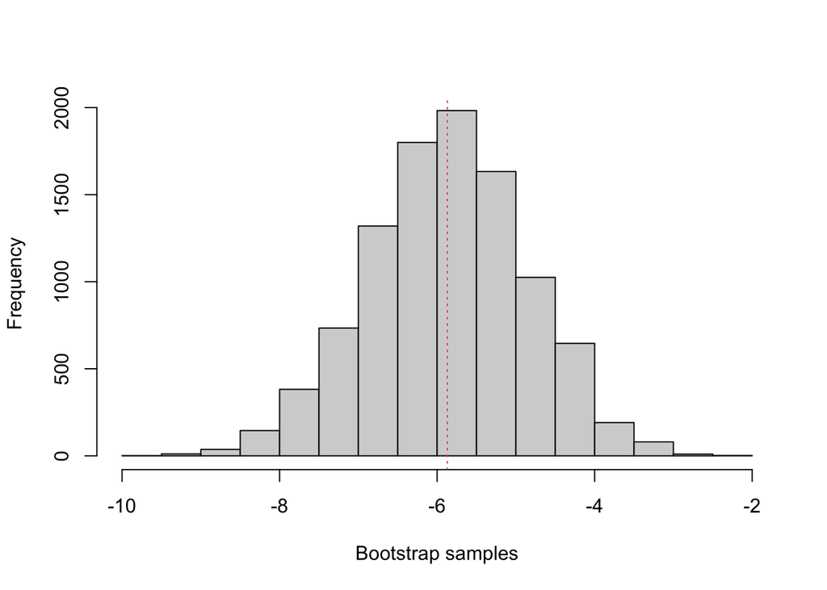

```r
hist(pen_boot)
```

### Tree data

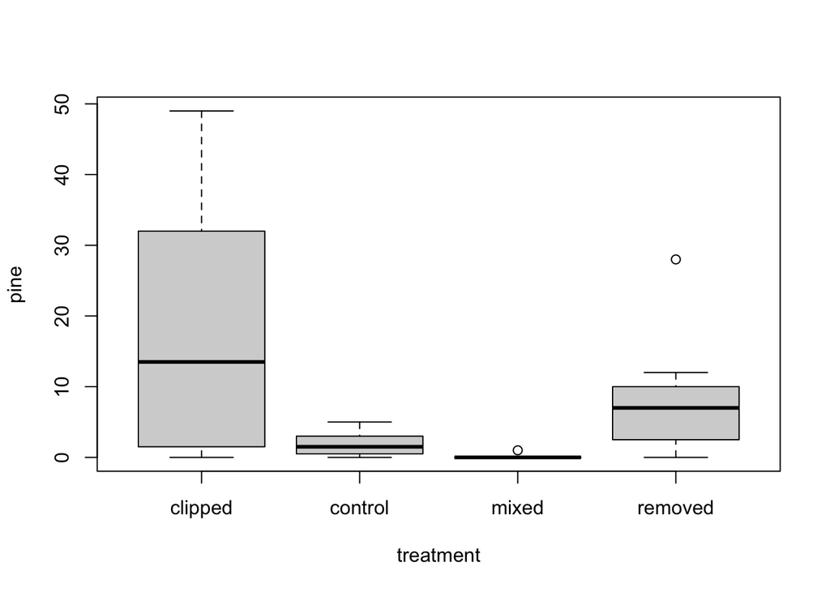

```r
boxplot(pine ~ treatment, dat = veg)
```

### Tree Treatments

```r
dat_tree = droplevels(subset(veg, treatment %in% c("control", "clipped")))
control_tree = subset(dat_tree, treatment == "control")
clipped_tree = subset(dat_tree, treatment == "clipped")

table(subset(dat_tree, treatment == "clipped")$pine)
```

```
##
##  0  3 11 16 17 47 49
##  2  1  1  1  1  1  1
```

### Nonparametric two-sample test

```r
wilcox.test(pine ~ treatment, data = dat_tree)
```

```
##
##  Wilcoxon rank sum test with continuity correction
##
## data:  pine by treatment
## W = 48, p-value = 0.1005
## alternative hypothesis: true location shift is not equal to 0
```

### Bootstrap

```r
tree_boot =
  two.boot(
    subset(dat_tree, treatment == "clipped")$pine,
    subset(dat_tree, treatment == "control")$pine,
    FUN = mean,
    R = 10000,
    na.rm = TRUE
  )

# sum(tree_boot$t >= 0)
# sum(tree_boot$t < 0)

boot.ci(tree_boot)
```

```
## BOOTSTRAP CONFIDENCE INTERVAL CALCULATIONS
## Based on 10000 bootstrap replicates
##
## CALL :
## boot.ci(boot.out = tree_boot)
##
## Intervals :
## Level      Normal              Basic
## 95%   ( 3.11, 28.82 )   ( 2.50, 27.62 )
##
## Level     Percentile            BCa
## 95%   ( 4.38, 29.50 )   ( 5.00, 30.75 )
## Calculations and Intervals on Original Scale
```

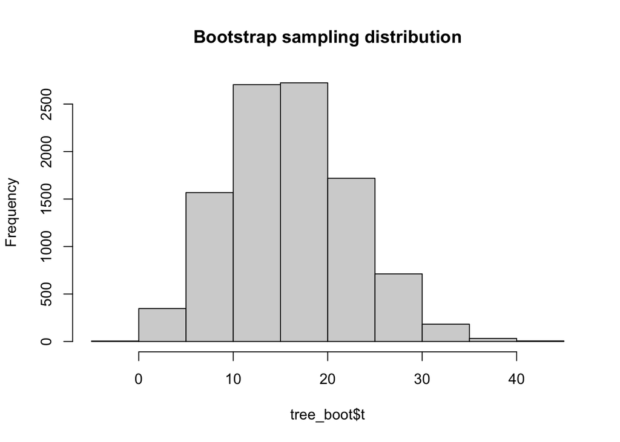

```r
hist(tree_boot$t, main = "Bootstrap sampling distribution")
```

```r
quantile(tree_boot$t, 0.025)
```

```
##  2.5%
## 4.375
```

## Resampling: linear regression

### Bird Data

```r
# dat_bird = read.csv(rmd.utils::find_file("bird.sub.csv"))
# dat_habitat = read.csv(rmd.utils::find_file("hab.sub.csv"))

dat_all = merge(
  dat_bird,
  dat_hab,
  by = c("basin", "sub"))
head(dat_all[, c("b.sidi", "s.sidi")])
```

```
##       b.sidi s.sidi
## 1 0.06678912   0.12
## 2 0.06509689   0.34
## 3 0.06092608   0.78
## 4 0.06012721   0.57
## 5 0.04112905   0.84
## 6 0.06086158   0.73
```

```r
# Calculate the sample mean and sd:
b_sidi_mean = mean(dat_all$b.sidi, na.rm = TRUE)
b_sidi_sd   = sd(dat_all$b.sidi, na.rm = TRUE)

# Use the subset-by-name symbol ($) to create a
# new column of z-standardized values.

dat_all$b.sidi.standardized = (dat_all$b.sidi - b_sidi_mean)/b_sidi_sd

mean(dat_all$b.sidi.standardized)
```

```
## [1] 7.166938e-17
```

```r
sd(dat_all$b.sidi.standardized)
```

```
## [1] 1
```

### Model Variables

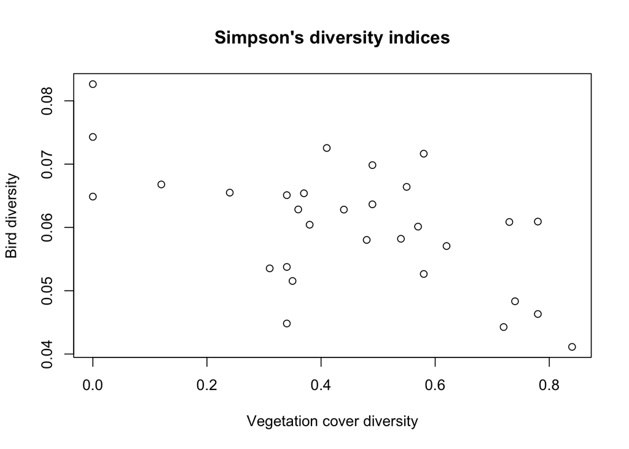

```r
plot(
  b.sidi ~ s.sidi, data = dat_all,
  main = "Simpson's diversity indices",
  xlab = "Vegetation cover diversity",
  ylab = "Bird diversity")
```

### Simple Linear Regression

```r
fit_1 = lm(b.sidi ~ s.sidi, data = dat_all)
coef(fit_1)
```

```
## (Intercept)      s.sidi
##  0.07116980 -0.02437131
```

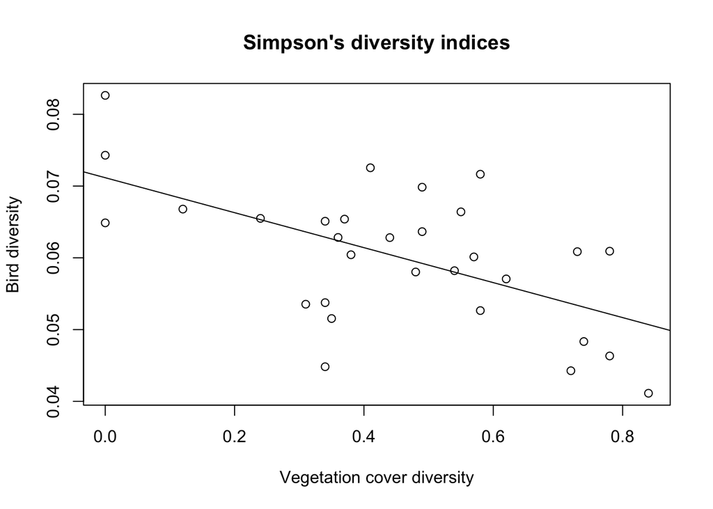

```r
slope_observed = coef(fit_1)[2]

plot(
  b.sidi ~ s.sidi, data = dat_all,
  main = "Simpson's diversity indices",
  xlab = "Vegetation cover diversity",
  ylab = "Bird diversity")
abline(fit_1)
```

### The Slope Coefficient

```r
dat_1 =
  subset(
    dat_all,
    select = c(b.sidi, s.sidi))

index_1 = sample(nrow(dat_1), replace = TRUE)
index_2 = sample(nrow(dat_1), replace = TRUE)

dat_resampled_i =
  data.frame(
    b.sidi = dat_1$b.sidi[index_1],
    s.sidi = dat_1$s.sidi[index_2]
  )

fit_resampled_i = lm(b.sidi ~ s.sidi, data = dat_resampled_i)
slope_resampled_i = coef(fit_resampled_i)[2]

print(slope_resampled_i)
```

```
##      s.sidi
## -0.01151686
```

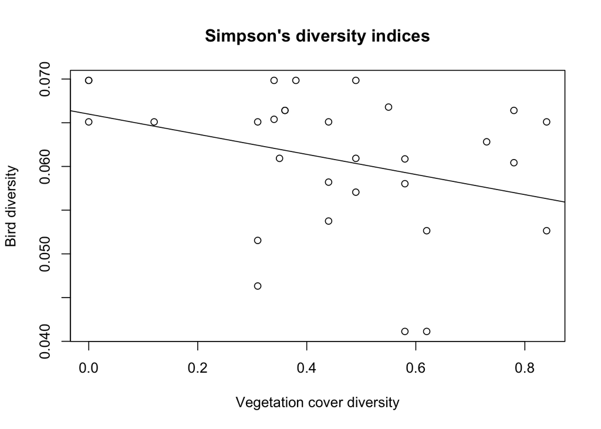

```r
plot(
  b.sidi ~ s.sidi, data = dat_resampled_i,
  main = "Simpson's diversity indices",
  xlab = "Vegetation cover diversity",
  ylab = "Bird diversity")
abline(fit_resampled_i)
```

### Randomization Loop

```r
m = 10000
result = numeric(m)

for(i in 1:m)
{
  index_1 = sample(nrow(dat_1), replace = TRUE)
  index_2 = sample(nrow(dat_1), replace = TRUE)

  dat_resampled_i = data.frame(
    b.sidi = dat_1$b.sidi[index_1],
    s.sidi = dat_1$s.sidi[index_2]
  )

  fit_resampled_i = lm(b.sidi ~ s.sidi, data = dat_resampled_i)
  result[i] = coef(fit_resampled_i)[2]
}
head(result)
```

```
## [1]  0.004034627 -0.001587375 -0.003995857  0.003996803  0.002102967
## [6] -0.011193819
```

### The Null Distribution

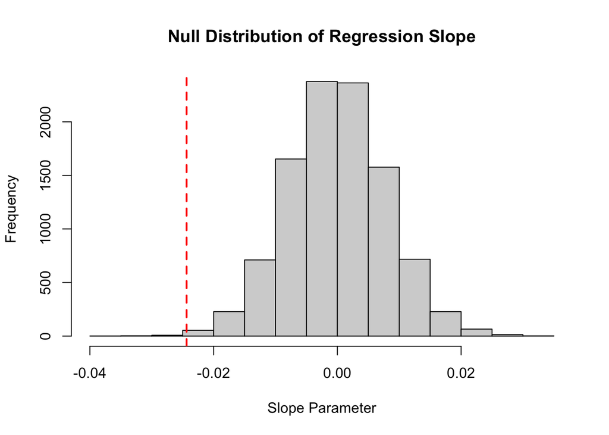

```r
hist(result, main = "Null Distribution of Regression Slope", xlab = "Slope Parameter")
abline(v = slope_observed, lty = 2, col = "red", lwd = 2)
```

### Critical Slope Value

```r
quantile(result, c(.05))
```

```
##          5%
## -0.01287503
```

# Lab Questions

## Question 1

### Calculate the standard deviation of the differences in mean flipper length from your bootstrap simulation. Show the R-code you used to find do the calculation.

```r
adelie = subset(penguins, species == "Adelie")
chinstrap = subset(penguins, species == "Chinstrap")

boot_mean = function(x, i)
{
  return(mean(x[i], na.rm = TRUE))
}

pen_boot =
  two.boot(
    adelie$flipper_length_mm,
    chinstrap$flipper_length_mm,
    FUN = boot_mean,
    R = 10000,
    )

sd(pen_boot$t)
```

```
## [1] 1.007913
```

```r
mean(pen_boot$t)
```

```
## [1] -5.876215
```

```r
median(pen_boot$t)
```

```
## [1] -5.878033
```

## Question 2

### Include your histogram in your lab report (you don’t need to show the R-code but make sure your plot includes appropriate title, axes, etc.).

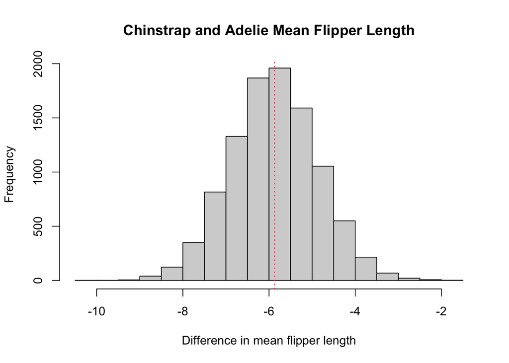

```r
hist(pen_boot, main = "Chinstrap and Adelie Mean Flipper Length", xlab = "Difference in mean flipper length")
```

## Question 3

### What was the 95% bootstrap CI you calculated using quantile()? Show the R-code you used to answer the question.

```r
quantile(pen_boot$t, c(0.025, 0.975))
```

```
##      2.5%     97.5%
## -7.835509 -3.903721
```

## Question 4

### Do you think the resampled differences in means follow a skewed distribution? Your answer should make reference to the mean, median, and histogram of the differences in means.

I don’t think that they follow a skewed distribution. The mean and median differ by very little, and the histogram shows an almost perfectly symmetrical bell shape. There isn’t anything skewed about this distribution.

## Question 5

### Show the R-code you used to create pen_ecdf()

```r
pen_ecdf = ecdf(pen_boot$t)
```

## Question 6

### What is the probability, according to the empirical distribution function, of observing a mean difference of -4.5 or greater? Show the R code you used to perform the calculation.

```r
1 - pen_ecdf(-4.5)
```

```
## [1] 0.0863
```

## Question 7

### What is the probability, according to the empirical distribution function, of observing a mean difference of -8 or smaller? Show the R code you used to perform the calculation.

```r
pen_ecdf(-8)
```

```
## [1] 0.017
```

## Question 8

### State the null and alternative hypotheses of a two-sample, two-tailed test for the difference in mean flipper lengths between the two penguin species.

The null hypothesis is that there is no difference in the mean flipper lengths between the two penguin species. The alternative test is that there is a (measurable) difference in the mean flipper lengths.

## Question 9

### What was the p-value? Show the R-code you used to find out.

The p-value was 0.1005

```r
# veg = read.csv(here("data", "vegdata.csv"))
head(veg)
```

```
##   block plot date treatment birch pine fern
## 1     A   A3 1995   control     0    4  260
## 2     A   A7 1995   control     0    0  186
## 3     A   A4 1995   removed     8    8   46
## 4     A   A6 1995   removed     6   28    1
## 5     A   A5 1995     mixed     0    1  309
## 6     A   A8 1995     mixed     0    0  258
```

```r
dat_veg = droplevels(subset(veg, treatment %in% c("control", "clipped")))
head(dat_veg)
```

```
##    block plot date treatment birch pine fern
## 1      A   A3 1995   control     0    4  260
## 2      A   A7 1995   control     0    0  186
## 7      A   A1 1995   clipped     0   11    0
## 8      A   A2 1995   clipped     2    0    0
## 9      B   B5 1995   control     0    5  256
## 10     B   B8 1995   control     0    0  247
```

```r
wilcox.test(pine ~ treatment, data = dat_veg)
```

```
##
##  Wilcoxon rank sum test with continuity correction
##
## data:  pine by treatment
## W = 48, p-value = 0.1005
## alternative hypothesis: true location shift is not equal to 0
```

## Question 10

### What were the endpoints of your bootstrap CI? Show the R-code you used to find out.

4.125 to 29.875

```r
# require(simpleboot)
set.seed(45454)

tree_boot =
  two.boot(
    subset(dat_tree, treatment == "clipped")$pine,
    subset(dat_tree, treatment == "control")$pine,
    FUN = mean,
    R = 10000,
    na.rm = TRUE
  )

quantile(tree_boot$t, c(0.025, 0.975))
```

```
##   2.5%  97.5%
##  4.125 29.875
```

## Question 11

### What is the observed difference in mean tree counts and does it fall within the 95% bootstrap CI?

The observed difference between the means is 16. 16 does fall within the 95% bootstrap CI (4.125 to 29.875).

```r
mean(subset(dat_veg, treatment == "clipped")$pine) -
mean(subset(dat_veg, treatment == "control")$pine)
```

```
## [1] 16
```

## Question 12

### Briefly describe the Simpson diversity index, and explain what it quantifies.

The Simpson diversity index is made up of two indices, b.sidi and s.sidi. b.sidi describes the diversity of the birds breeding at a site and s.sidi represents the diversity of the vegetation at a site (landscape diversity).

## Question 13

### Show the code you used to z-standardize the s.sidi column.

```r
# dat_bird = read.csv(rmd.utils::find_file("bird.sub.csv"))
# dat_hab = read.csv(rmd.utils::find_file("hab.sub.csv"))

dat_all = merge(
  dat_bird,
  dat_hab,
  by = c("basin", "sub"))
head(dat_all[, c("b.sidi", "s.sidi")])
```

```
##       b.sidi s.sidi
## 1 0.06678912   0.12
## 2 0.06509689   0.34
## 3 0.06092608   0.78
## 4 0.06012721   0.57
## 5 0.04112905   0.84
## 6 0.06086158   0.73
```

```r
b_sidi_mean = mean(dat_all$b.sidi, na.rm = TRUE)
b_sidi_sd   = sd(dat_all$b.sidi, na.rm = TRUE)

dat_all$b.sidi.standardized = (dat_all$b.sidi - b_sidi_mean)/b_sidi_sd

# Z-standardization code:
s_sidi_mean = mean(dat_all$s.sidi, na.rm = TRUE)
s_sidi_sd = sd(dat_all$s.sidi, na.rm = TRUE)

dat_all$s.sidi.stardardized = (dat_all$s.sidi - s_sidi_mean) / s_sidi_sd
```

## Question 14

### Show the code for your completed loop.

```r
set.seed(45454)
fit_1 = lm(b.sidi ~ s.sidi, data = dat_all)
coef(fit_1)
```

```
## (Intercept)      s.sidi
##  0.07116980 -0.02437131
```

```r
slope_observed = coef(fit_1)[2]

dat_1 =
  subset(
    dat_all,
    select = c(b.sidi, s.sidi))

m = 10000
result = numeric(m)

for(i in 1:m)
{
  index_1 = sample(nrow(dat_1), replace = TRUE)
  index_2 = sample(nrow(dat_1), replace = TRUE)

  dat_resampled_i =
    data.frame(
      b.sidi = dat_1$b.sidi[index_1],
      s.sidi = dat_1$s.sidi[index_2]
    )

  fit_resampled_i = lm(b.sidi ~ s.sidi, data = dat_resampled_i)
  result[i] = coef(fit_resampled_i)[2]
}
head(result)
```

```
## [1] -0.001115819 -0.014394589 -0.005813216 -0.004918155 -0.008929510
## [6]  0.002738082
```

## Question 15

### In your report, include a plot of your histogram with vertical lines showing the observed slope and the critical value from the resampled MC slopes.

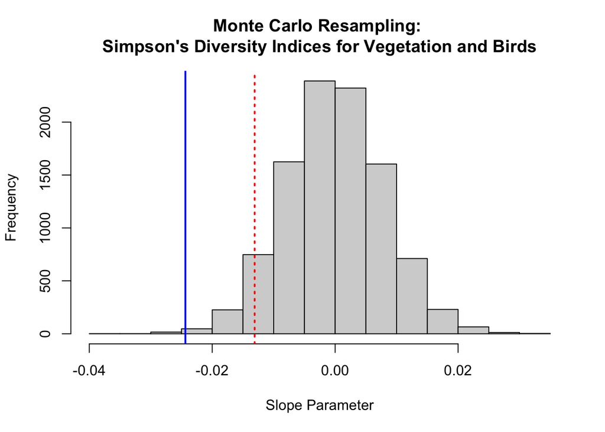

```r
hist(result, main = "Monte Carlo Resampling: \nSimpson's Diversity Indices for Vegetation and Birds", xlab = "Slope Parameter")
abline(v = slope_observed, col = "blue", lwd = 2)
abline(v = quantile(result, 0.05), col = "red", lty = "dotted", lwd = 2)
```

## Question 16

### What was your critical value? Was the observed slope less than the critical value?

```r
quantile(result, 0.05)
```

```
##          5%
## -0.01309684
```

```r
print(slope_observed)
```

```
##      s.sidi
## -0.02437131
```

## Question 17

### What is your conclusion regarding the evidence of a negative relationship between vegetation cover diversity and bird diversity? Make sure to justify your conclusions using the results of your analysis.

It seems like there is in fact evidence of a negative relationship between vegetation cover density and bird diversity. Because the observed slope that I calculated is less than the critical value, 95% of the time the Monte Carlo sampling is repeated we’ll observe a slope greater than -0.01309. If there wasn’t a relationship, the slope coefficient would only be -0.01309 5% of the time.